# swst wolbachia maps+ TEEseq + eggs + hatch

Dan Bruzzese

7/23/2020

# Fig1 collection map

mayabe add an insert with macro photos of both flies

```
## [1] 24
```

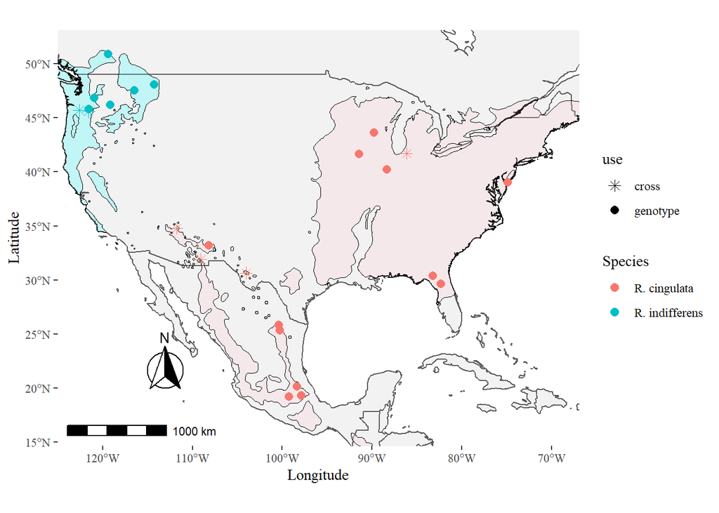

# S1 Table

| ID | pop | Species | host | Locality | lat | lon | n | wCin2 | wCin2_3 | wCin3 |
| --- | --- | --- | --- | --- | --- | --- | --- | --- | --- | --- |
| alA | West | R. indifferens | P.emarginata | Salmon Arm, BC, Can | 50.91500 | -119.35722 | 8 | 8 | 0 | 0 |
| cinAZ | SW | R. cingulata | P.serotina | Chriacahoua Mtns, AZ | 31.92889 | -109.08750 | 7 | 0 | 7 | 0 |
| cinCoa | SW | R. cingulata | P.serotina | Los Lirios, Coahuila, Mex | 25.34944 | -100.29611 | 7 | 0 | 7 | 0 |
| cinDF | SW | R. cingulata | P.serotina | Districto Federal, Mex | 19.22787 | -99.26764 | 6 | 0 | 6 | 0 |
| cinFL1 | East | R. cingulata | P.serotina | Live Oak, Suwannee County, FL | 30.36833 | -83.24389 | 7 | 7 | 0 | 0 |
| cinFL2 | East | R. cingulata | P.serotina | UniFL-Health, Gainesville, FL | 29.64402 | -82.35516 | 7 | 7 | 0 | 0 |
| cinIL | East | R. cingulata | P.serotina | Lake of the woods, IL | 40.20003 | -88.38464 | 8 | 8 | 0 | 0 |
| cinIN | East | R. cingulata | P.serotina | South Bend, IN | 41.69762 | -86.17200 | 7 | 7 | 0 | 0 |
| cinIO | East | R. cingulata | P.serotina | Scott Park, Iowa City, IO | 41.65340 | -91.48029 | 8 | 8 | 0 | 0 |
| cinNJ | East | R. cingulata | P.serotina | Green Creek, Cape May, NJ | 39.03639 | -74.90139 | 7 | 7 | 0 | 0 |
| cinNL | SW | R. cingulata | P.serotina | Nuevo León, Mex | 25.81333 | -100.36722 | 8 | 1 | 7 | 0 |
| cinNM | SW | R. cingulata | P.serotina | Gila Cliff Dwelling Mon., NM | 33.17889 | -108.20389 | 8 | 1 | 7 | 0 |
| cinTula | SW | R. cingulata | P.serotina | Tulancingo, Mex | 20.13430 | -98.38022 | 7 | 6 | 1 | 0 |
| cinTX | SW | R. cingulata | P.serotina | Davis Mountains, TX | 30.64639 | -104.01889 | 7 | 0 | 7 | 0 |
| cinTxl | SW | R. cingulata | P.serotina | Huamantla, Tlaxcala, Mex | 19.31500 | -97.87444 | 6 | 0 | 1 | 5 |
| cinWI | East | R. cingulata | P.serotina | The Dells, Wisconson Dells, WI | 43.64314 | -89.78329 | 6 | 6 | 0 | 0 |
| indAlki | West | R. indifferens | P.emarginata? | Vancouver, WA | 45.68281 | -122.59908 | 7 | 7 | 0 | 0 |
| indApl | West | R. indifferens |  | Aplin Rd., White Salmon, WA | 45.78332 | -121.50542 | 8 | 8 | 0 | 0 |
| indID | West | R. indifferens | P.emarginata | Rose Lake, ID | 47.53869 | -116.47287 | 8 | 8 | 0 | 0 |
| indKen | West | R. indifferens |  | Kennewick, WA | 46.20719 | -119.12694 | 5 | 5 | 0 | 0 |
| indMT | West | R. indifferens |  | Somers, MT | 48.09000 | -114.23000 | 5 | 5 | 0 | 0 |
| indNil | West | R. indifferens |  | Nile, WA | 46.82020 | -120.93969 | 5 | 5 | 0 | 0 |
| cinOak | SW | R. cingulata | P. serotina | Oak Creek, AZ | 34.78717 | -111.75535 | NA | NA | NA | NA |
| indHill | West | R. indifferens | P.emarginata | Hillcrest Rd, Hood River, OR | 45.58266 | -121.55664 | NA | NA | NA | NA |

# Fig2 TEEseq map

should I make the universal swest strain (wCin2) into wCin4???

```
## [1] 22
```

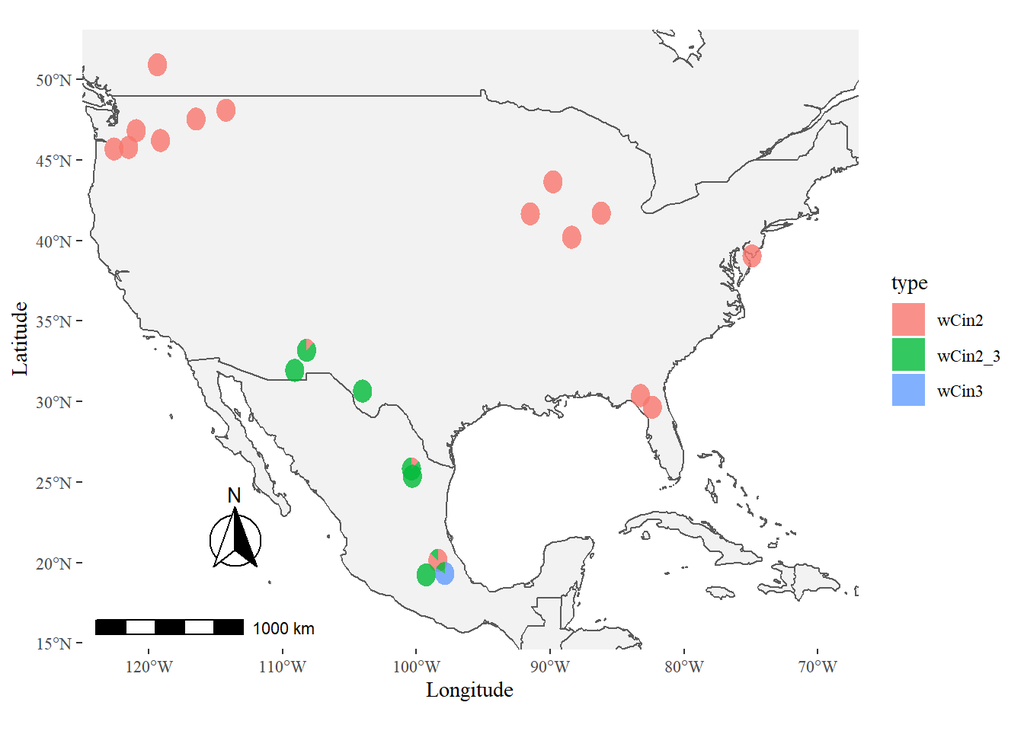

# premating

how am I going to put p values to this? It’s just a descriptive stat at this point…  
looks like indifferens females are choosy and cingulata females are not. In hybrid crosses btween populations along the cline, indifferens females prefer sw males over east males. Makes sense.

### matings / hour

| female.pop | East | West | Southwest |
| --- | --- | --- | --- |
| East | 0.2790698 | 0.3181818 | 0.3000000 |
| West | 0.1379310 | 1.1555556 | 0.3571429 |
| Southwest | 0.1200000 | 0.4000000 | 0.6666667 |

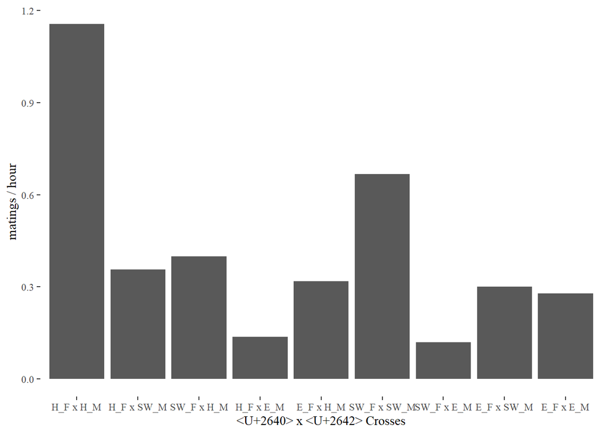

### premating isolation index

-1 = dissasortative mating  
0 = random mating  
1 = assortative mating  
1 - (2 * (H / (H + C)))

```
## [1] "west x SW"
```

```
##   Southwest
## 1 0.4129231
```

```
## [1] "west x East"
```

```
##        East
## 1 0.5175293
```

```
## [1] "SW X East"
```

```
##        East
## 1 0.3849472
```

## basic crossing stats

```
## [1] 217
```

```
## [1] East_x_East West_x_West SW_x_SW     West_x_SW   SW_x_West   East_x_West
## [7] West_x_East East_x_SW   SW_x_East
## 9 Levels: East_x_East < East_x_SW < SW_x_East < SW_x_SW < ... < East_x_West
```

| name | number |
| --- | --- |
| East_x_East | 11 |
| East_x_SW | 14 |
| SW_x_East | 9 |
| SW_x_SW | 51 |
| SW_x_West | 25 |
| West_x_SW | 23 |
| West_x_West | 54 |
| West_x_East | 16 |
| East_x_West | 14 |

# Fig3 total eggs laid for pure and hybrid crosses

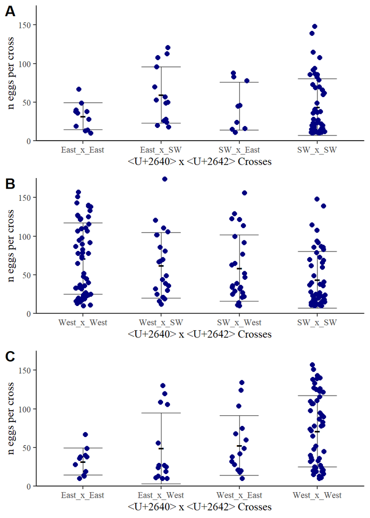

### sig difference between all crosses

```
## # A tibble: 1 x 6
##   .y.        n statistic    df     p method
## * <chr>  <int>     <dbl> <int> <dbl> <chr>
## 1 n_eggs   217      18.2     8  0.02 Kruskal-Wallis
```

```
## # A tibble: 1 x 5
##   .y.        n effsize method  magnitude
## * <chr>  <int>   <dbl> <chr>   <ord>
## 1 n_eggs   217  0.0489 eta2[H] small
```

### no diff btwn crosses with sw males and all other crosses

```
## # A tibble: 1 x 6
##   .y.        n statistic    df     p method
## * <chr>  <int>     <dbl> <int> <dbl> <chr>
## 1 n_eggs   217      1.78     1 0.182 Kruskal-Wallis
```

```
## # A tibble: 1 x 5
##   .y.        n effsize method  magnitude
## * <chr>  <int>   <dbl> <chr>   <ord>
## 1 n_eggs   217 0.00365 eta2[H] small
```

### East X SW kruskal-Wallis test

no sig

```
## # A tibble: 4 x 7
##   name        pop.Female pop.Male  mean    sd   sem ci
##   <ord>       <ord>      <ord>    <dbl> <dbl> <dbl> <chr>
## 1 East_x_East East       East      32    17.4  5.24 WT
## 2 East_x_SW   East       SW        59.5  36.5  9.76 CI
## 3 SW_x_East   SW         East      45.1  31.1 10.4  WT
## 4 SW_x_SW     SW         SW        43.6  36.6  5.13 WT
```

```
## # A tibble: 1 x 6
##   .y.        n statistic    df     p method
## * <chr>  <int>     <dbl> <int> <dbl> <chr>
## 1 n_eggs    85      5.15     3 0.161 Kruskal-Wallis
```

```
## # A tibble: 1 x 5
##   .y.        n effsize method  magnitude
## * <chr>  <int>   <dbl> <chr>   <ord>
## 1 n_eggs    85  0.0265 eta2[H] small
```

### West X SW kruskal-Wallis test and Dunn’s test of multiple comparisons

sig diff

```
## # A tibble: 4 x 7
##   name        pop.Female pop.Male  mean    sd   sem ci
##   <ord>       <ord>      <ord>    <dbl> <dbl> <dbl> <chr>
## 1 West_x_West West       West      71.1  46.2  6.29 WT
## 2 West_x_SW   West       SW        62.3  42.3  8.83 CI
## 3 SW_x_West   SW         West      59.0  42.9  8.59 WT
## 4 SW_x_SW     SW         SW        43.6  36.6  5.13 WT
```

```
## # A tibble: 1 x 6
##   .y.        n statistic    df       p method
## * <chr>  <int>     <dbl> <int>   <dbl> <chr>
## 1 n_eggs   153      12.7     3 0.00537 Kruskal-Wallis
```

```
## # A tibble: 1 x 5
##   .y.        n effsize method  magnitude
## * <chr>  <int>   <dbl> <chr>   <ord>
## 1 n_eggs   153  0.0650 eta2[H] moderate
```

| .y. | group1 | group2 | n1 | n2 | statistic | p | p.adj | p.adj.signif |
| --- | --- | --- | --- | --- | --- | --- | --- | --- |
| n_eggs | West_x_West | West_x_SW | 54 | 23 | -0.6239990 | 0.5326283 | 1.0000000 | ns |
| n_eggs | West_x_West | SW_x_West | 54 | 25 | -0.9677060 | 0.3331912 | 1.0000000 | ns |
| n_eggs | West_x_West | SW_x_SW | 54 | 51 | -3.4685232 | 0.0005233 | 0.0076929 | ** |
| n_eggs | West_x_SW | SW_x_West | 23 | 25 | -0.2724692 | 0.7852613 | 1.0000000 | ns |
| n_eggs | West_x_SW | SW_x_SW | 23 | 51 | -2.0778499 | 0.0377232 | 0.2772654 | ns |
| n_eggs | SW_x_West | SW_x_SW | 25 | 51 | -1.8151715 | 0.0694976 | 0.3405380 | ns |

### East X West kruskal-Wallis test

```
## # A tibble: 4 x 7
##   name        pop.Female pop.Male  mean    sd   sem ci
##   <ord>       <ord>      <ord>    <dbl> <dbl> <dbl> <chr>
## 1 East_x_East East       East      32    17.4  5.24 WT
## 2 East_x_West East       West      49.1  45.9 12.3  WT
## 3 West_x_East West       East      52.8  38.8  9.70 WT
## 4 West_x_West West       West      71.1  46.2  6.29 WT
```

```
## # A tibble: 1 x 6
##   .y.        n statistic    df      p method
## * <chr>  <int>     <dbl> <int>  <dbl> <chr>
## 1 n_eggs    95      8.25     3 0.0412 Kruskal-Wallis
```

```
## # A tibble: 1 x 5
##   .y.        n effsize method  magnitude
## * <chr>  <int>   <dbl> <chr>   <ord>
## 1 n_eggs    95  0.0577 eta2[H] small
```

| .y. | group1 | group2 | n1 | n2 | statistic | p | p.adj | p.adj.signif |
| --- | --- | --- | --- | --- | --- | --- | --- | --- |
| n_eggs | East_x_East | East_x_West | 11 | 14 | 0.4283164 | 0.6684208 | 1.0000000 | ns |
| n_eggs | East_x_East | West_x_East | 11 | 16 | 1.1134283 | 0.2655245 | 0.9758026 | ns |
| n_eggs | East_x_East | West_x_West | 11 | 54 | 2.3421295 | 0.0191741 | 0.2818587 | ns |
| n_eggs | East_x_West | West_x_East | 14 | 16 | 0.7200959 | 0.4714659 | 1.0000000 | ns |
| n_eggs | East_x_West | West_x_West | 14 | 54 | 2.0079209 | 0.0446517 | 0.3281900 | ns |
| n_eggs | West_x_East | West_x_West | 16 | 54 | 1.1898328 | 0.2341121 | 0.9758026 | ns |

Dunn’s test p value is adjusted with “by” the FDR is controlled using the Benjamini-Yekutieli adjustment (2011),

“by” the FDR is controlled using the Benjamini-Yekutieli adjustment (2011), a step-down procedure appropriate to depenent tests. p-values are ordered from largest to smallest, and adjusted p-values = max[1, pmC/(m+1-i)], where i indexes the ordering, and the constant C = 1 + 1/2 + . . . + 1/m. All tests after and including the first to be rejected are also rejected.

# Fig 4 hatch rate

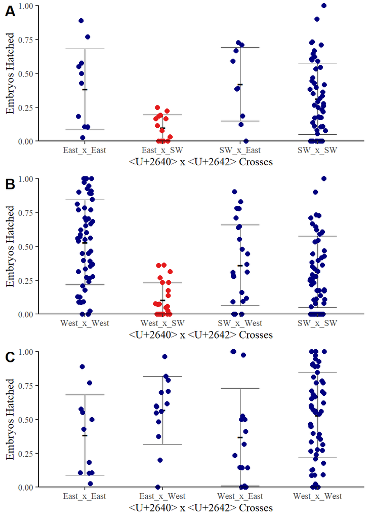

### sig difference between all crosses

```
## # A tibble: 1 x 6
##   .y.            n statistic    df           p method
## * <chr>      <int>     <dbl> <int>       <dbl> <chr>
## 1 hatch_rate   217      52.1     8 0.000000016 Kruskal-Wallis
```

```
## # A tibble: 1 x 5
##   .y.            n effsize method  magnitude
## * <chr>      <int>   <dbl> <chr>   <ord>
## 1 hatch_rate   217   0.212 eta2[H] large
```

### sig diff btwn crosses with sw males and all other crosses

```
## # A tibble: 1 x 6
##   .y.            n statistic    df             p method
## * <chr>      <int>     <dbl> <int>         <dbl> <chr>
## 1 hatch_rate   217      35.4     1 0.00000000263 Kruskal-Wallis
```

```
## # A tibble: 1 x 5
##   .y.            n effsize method  magnitude
## * <chr>      <int>   <dbl> <chr>   <ord>
## 1 hatch_rate   217   0.160 eta2[H] large
```

### East X SW kruskal-Wallis test and Dunn’s test of multiple comparisons

sig diff

```
## # A tibble: 4 x 7
##   name        pop.Female pop.Male  mean     sd    sem ci
##   <ord>       <ord>      <ord>    <dbl>  <dbl>  <dbl> <chr>
## 1 East_x_East East       East     0.385 0.297  0.0896 WT
## 2 East_x_SW   East       SW       0.101 0.0954 0.0255 CI
## 3 SW_x_East   SW         East     0.421 0.271  0.0904 WT
## 4 SW_x_SW     SW         SW       0.313 0.265  0.0370 WT
```

```
## # A tibble: 1 x 6
##   .y.            n statistic    df      p method
## * <chr>      <int>     <dbl> <int>  <dbl> <chr>
## 1 hatch_rate    85      11.1     3 0.0112 Kruskal-Wallis
```

```
## # A tibble: 1 x 5
##   .y.            n effsize method  magnitude
## * <chr>      <int>   <dbl> <chr>   <ord>
## 1 hatch_rate    85  0.0999 eta2[H] moderate
```

| .y. | group1 | group2 | n1 | n2 | statistic | p | p.adj | p.adj.signif |
| --- | --- | --- | --- | --- | --- | --- | --- | --- |
| hatch_rate | East_x_East | East_x_SW | 11 | 14 | -2.5922408 | 0.0095353 | 0.0467230 | * |
| hatch_rate | East_x_East | SW_x_East | 11 | 9 | 0.4166072 | 0.6769657 | 1.0000000 | ns |
| hatch_rate | East_x_East | SW_x_SW | 11 | 51 | -0.7099619 | 0.4777278 | 1.0000000 | ns |
| hatch_rate | East_x_SW | SW_x_East | 14 | 9 | 2.8828656 | 0.0039408 | 0.0467230 | * |
| hatch_rate | East_x_SW | SW_x_SW | 14 | 51 | 2.6793609 | 0.0073763 | 0.0467230 | * |
| hatch_rate | SW_x_East | SW_x_SW | 9 | 51 | -1.1707107 | 0.2417151 | 0.8883029 | ns |

### West X SW kruskal-Wallis test and Dunn’s test of multiple comparisons

sig diff

```
## # A tibble: 4 x 7
##   name        pop.Female pop.Male  mean    sd    sem ci
##   <ord>       <ord>      <ord>    <dbl> <dbl>  <dbl> <chr>
## 1 West_x_West West       West     0.530 0.313 0.0426 WT
## 2 West_x_SW   West       SW       0.106 0.127 0.0264 CI
## 3 SW_x_West   SW         West     0.363 0.297 0.0595 WT
## 4 SW_x_SW     SW         SW       0.313 0.265 0.0370 WT
```

```
## # A tibble: 1 x 6
##   .y.            n statistic    df           p method
## * <chr>      <int>     <dbl> <int>       <dbl> <chr>
## 1 hatch_rate   153      34.1     3 0.000000192 Kruskal-Wallis
```

```
## # A tibble: 1 x 5
##   .y.            n effsize method  magnitude
## * <chr>      <int>   <dbl> <chr>   <ord>
## 1 hatch_rate   153   0.208 eta2[H] large
```

| .y. | group1 | group2 | n1 | n2 | statistic | p | p.adj | p.adj.signif |
| --- | --- | --- | --- | --- | --- | --- | --- | --- |
| hatch_rate | West_x_West | West_x_SW | 54 | 23 | -5.6768611 | 0.0000000 | 0.0000002 | **** |
| hatch_rate | West_x_West | SW_x_West | 54 | 25 | -2.1213992 | 0.0338882 | 0.0996314 | ns |
| hatch_rate | West_x_West | SW_x_SW | 54 | 51 | -3.4150237 | 0.0006378 | 0.0046876 | ** |
| hatch_rate | West_x_SW | SW_x_West | 23 | 25 | 3.1160606 | 0.0018328 | 0.0089809 | ** |
| hatch_rate | West_x_SW | SW_x_SW | 23 | 51 | 2.9727884 | 0.0029511 | 0.0108452 | * |
| hatch_rate | SW_x_West | SW_x_SW | 25 | 51 | -0.6292818 | 0.5291646 | 1.0000000 | ns |

### East X West kruskal-Wallis test

we see that there is no sig diff

| name | pop.Female | pop.Male | mean | sd | sem | ci |
| --- | --- | --- | --- | --- | --- | --- |
| East_x_East | East | East | 0.3854656 | 0.2972275 | 0.0896175 | WT |
| East_x_West | East | West | 0.5678520 | 0.2499078 | 0.0667907 | WT |
| West_x_East | West | East | 0.3686978 | 0.3589131 | 0.0897283 | WT |
| West_x_West | West | West | 0.5303107 | 0.3128826 | 0.0425779 | WT |

| .y. | n | statistic | df | p | method |
| --- | --- | --- | --- | --- | --- |
| hatch_rate | 95 | 5.551908 | 3 | 0.136 | Kruskal-Wallis |

```
## # A tibble: 1 x 5
##   .y.            n effsize method  magnitude
## * <chr>      <int>   <dbl> <chr>   <ord>
## 1 hatch_rate    95  0.0280 eta2[H] small
```

Dunn’s test p value is adjusted with “by” the FDR is controlled using the Benjamini-Yekutieli adjustment (2011),

“by” the FDR is controlled using the Benjamini-Yekutieli adjustment (2011), a step-down procedure appropriate to depenent tests. p-values are ordered from largest to smallest, and adjusted p-values = max[1, pmC/(m+1-i)], where i indexes the ordering, and the constant C = 1 + 1/2 + . . . + 1/m. All tests after and including the first to be rejected are also rejected.